# Cap experiment

- Batch - B
- Group Number - 5
- Task 2.1 Sales/Profit Analysis
- Group Member Name - Vishnu S

```python
import pandas as pd
import numpy as np
import os
import seaborn as sns
import matplotlib.pyplot as plt
sns.set_theme(style="whitegrid")
```

```python
pwd
```

```
'C:\\Users\\vishnus4'
```

```python
cd C:\Users\vishnus4\Documents\AI
```

```
C:\Users\vishnus4\Documents\AI
```

```python
pwd
```

```
'C:\\Users\\vishnus4\\Documents\\AI'
```

```python
df= pd.read_csv("Store_Modified.csv")
df.head()
```

|  | Row_ID | Order_ID | Order_Date | Ship_Date | Ship_Mode | Customer_ID | Customer_Name | Segment | Country | City_Code | ... | Postal_Code | Product_ID | Category | Sub-Category | Product_Name | Sales | Quantity | Discount | Profit | Duration |
| --- | --- | --- | --- | --- | --- | --- | --- | --- | --- | --- | --- | --- | --- | --- | --- | --- | --- | --- | --- | --- | --- |
| 0 | 1 | CA-2013-152156 | 11/9/2013 | 11/12/2013 | Second Class | CG-12520 | Claire Gute | Consumer | United States | C259 | ... | 42420 | FUR-BO-10001798 | Furniture | Bookcases | Bush Somerset Collection Bookcase | 261.9600 | 2 | 0.00 | 41.9136 | 3 days |
| 1 | 2 | CA-2013-152156 | 11/9/2013 | 11/12/2013 | Second Class | CG-12520 | Claire Gute | Consumer | United States | C259 | ... | 42420 | FUR-CH-10000454 | Furniture | Chairs | Hon Deluxe Fabric Upholstered Stacking Chairs,... | 731.9400 | 3 | 0.00 | 219.5820 | 3 days |
| 2 | 3 | CA-2013-138688 | 6/13/2013 | 6/17/2013 | Second Class | DV-13045 | Darrin Van Huff | Corporate | United States | C64 | ... | 90036 | OFF-LA-10000240 | Office Supplies | Labels | Self-Adhesive Address Labels for Typewriters b... | 14.6200 | 2 | 0.00 | 6.8714 | 4 days |
| 3 | 4 | US-2012-108966 | 10/11/2012 | 10/18/2012 | Standard Class | SO-20335 | Sean O'Donnell | Consumer | United States | C150 | ... | 33311 | FUR-TA-10000577 | Furniture | Tables | Bretford CR4500 Series Slim Rectangular Table | 957.5775 | 5 | 0.45 | -383.0310 | 7 days |
| 4 | 5 | US-2012-108966 | 10/11/2012 | 10/18/2012 | Standard Class | SO-20335 | Sean O'Donnell | Consumer | United States | C150 | ... | 33311 | OFF-ST-10000760 | Office Supplies | Storage | Eldon Fold 'N Roll Cart System | 22.3680 | 2 | 0.20 | 2.5164 | 7 days |

5 rows × 21 columns

### 1.The category of the product that earns highest profit.

##### Graphical Representation of product category that earns the highest profit

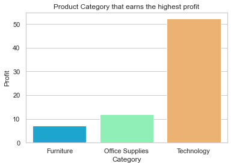

```python
sns.barplot(x='Category',y='Profit',data=df,palette='rainbow',ci=None)
plt.title('Product Category that earns the highest profit')
sns.set_theme(style="whitegrid")
```

Insights: The Technology category has the highest profit which means the sales for this category might be the highest too.

### 2.The segment which yields highest profit

```python
seg=df.groupby(['Segment'])['Profit'].sum()
seg_max = seg.max()
seg = pd.DataFrame(seg)
seg
```

| Segment | Profit |
| --- | --- |
| Consumer | 88714.0079 |
| Corporate | 50868.6196 |
| Home Office | 38671.7300 |

```python
print("The segment that earns the highest profit is consumer with a profit of : ",seg_max)
seg[seg["Profit"]==seg_max]
```

```
The segment that earns the highest profit is consumer with a profit of :  88714.0079
```

| Segment | Profit |
| --- | --- |
| Consumer | 88714.0079 |

##### Graphical Representation of segment that yields highest profit

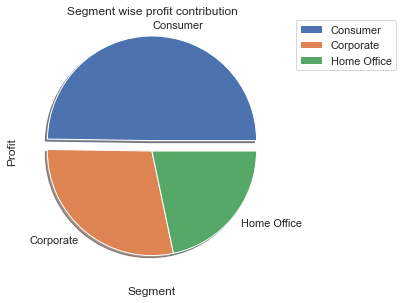

```python
explode = (0.1, 0,0)
seg.groupby(['Segment']).sum().plot(kind='pie', y='Profit',explode=explode,shadow=True)
plt.tight_layout()
plt.title('Segment wise profit contribution')
plt.xlabel('Segment')
plt.legend(bbox_to_anchor=(1.05, 1), loc=2, borderaxespad=0.)
```

Insights: Almost 50 percent of the total profit is yielded by the segment Consumer in which the category Technology contributes the highest, which is depicted in the below graph.

### Category of the product with highest demand in each segment

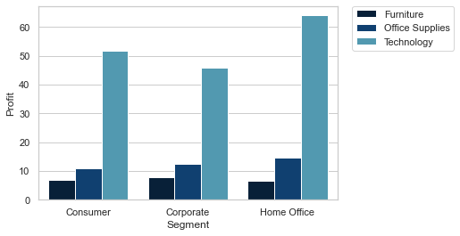

```python
sns.barplot(x='Segment',y='Profit',data=df,hue='Category',ci=None,palette='ocean')
plt.legend(bbox_to_anchor=(1.05, 1), loc=2, borderaxespad=0.)
```

Insight: In all the segments category "Technology" seems to be the highest in demand which infact means the sales is highest in technology.

### 3. The city with highest sales

```python
df1=pd.read_excel(r"C:\Users\vishnus4\Documents\AI\Capstone\Capstone7_Time Series\Tables\City_Table.xlsx")
df1.head()
```

|  | City_Code | State_Code | City_Name |
| --- | --- | --- | --- |
| 0 | C01 | S01 | Auburn |
| 1 | C02 | S01 | Decatur |
| 2 | C03 | S01 | Florence |
| 3 | C04 | S01 | Hoover |
| 4 | C05 | S01 | Huntsville |

```python
city_sales = df.groupby(['City_Code']).sum()['Sales']
city_sales = pd.DataFrame(city_sales)
city_sales = city_sales.reset_index()
df1 = pd.merge(df1,city_sales,how = 'inner')
df1 = pd.DataFrame(df1)
df1 = df1.sort_values("Sales", ascending=False)
df1
```

|  | City_Code | State_Code | City_Name | Sales |
| --- | --- | --- | --- | --- |
| 359 | C390 | S31 | New York City | 161406.884 |
| 63 | C64 | S04 | Los Angeles | 123338.131 |
| 90 | C91 | S04 | San Francisco | 81014.292 |
| 514 | C587 | S46 | Seattle | 80078.150 |
| 413 | C464 | S37 | Philadelphia | 78686.659 |
| ... | ... | ... | ... | ... |
| 162 | C164 | S09 | Ormond Beach | 2.808 |
| 165 | C167 | S09 | Pensacola | 2.214 |
| 153 | C155 | S09 | Jupiter | 2.064 |
| 384 | C426 | S34 | Elyria | 1.824 |
| 436 | C495 | S42 | Abilene | 1.392 |

530 rows × 4 columns

##### City with highest sales

```python
city_sales_max=df1['Sales'].max()
df1[df1["Sales"]==city_sales_max]
```

|  | City_Code | State_Code | City_Name | Sales |
| --- | --- | --- | --- | --- |
| 359 | C390 | S31 | New York City | 161406.884 |

##### Graphical representation of highest sales city wise

[output not shown]

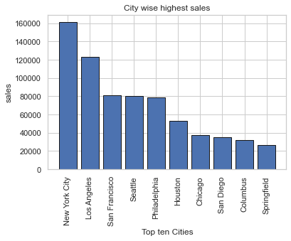

```python
Top_10_Cites=df1.head(10)
Top_10_Cites=pd.DataFrame(Top_10_Cites)
plt.bar(x='City_Name',data=Top_10_Cites,height='Sales',edgecolor='k')
plt.title('City wise highest sales')
plt.xlabel('Top ten Cities')
plt.ylabel('sales')
plt.xticks(rotation=90)
```

NOTE:Since there are more than 500 rows which makes the plotting difficult,only the top 10 cities have been considered.

Insight: This graph depicts the 10 highest city wise sales, in which New York City tops the chart. Which also means New York City tops the city wise profit share contribution too.

### 4. Percentage share of sales at every state

```python
df2 =pd.read_excel(r"C:\Users\vishnus4\Documents\AI\Capstone\Capstone7_Time Series\Tables\State_Table.xlsx")
state_sales = df.groupby(['State_Code']).sum()['Sales']
state_sales = pd.DataFrame(state_sales)
state_sales = state_sales.reset_index()
df2 = pd.merge(df2,state_sales,how = 'inner') # State wise sales
df2 =pd.DataFrame(df2)
df2.head()
```

|  | State_Code | State | Sales |
| --- | --- | --- | --- |
| 0 | S01 | Alabama | 14941.4600 |
| 1 | S02 | Arizona | 33222.2130 |
| 2 | S03 | Arkansas | 9192.1900 |
| 3 | S04 | California | 335491.7955 |
| 4 | S05 | Colorado | 26743.5010 |

##### Calculating the total sales in order to compute percentage and then calculating the percentage

```python
total_sales = df2['Sales'].sum()
total_sales = round(total_sales,2)
print("The sum of all sales, ie the total sales is: ",total_sales)
df2['percentage'] = df2['Sales']/total_sales*100
df2.head()
```

```
The sum of all sales, ie the total sales is:  1614536.35
```

|  | State_Code | State | Sales | percentage |
| --- | --- | --- | --- | --- |
| 0 | S01 | Alabama | 14941.4600 | 0.925433 |
| 1 | S02 | Arizona | 33222.2130 | 2.057694 |
| 2 | S03 | Arkansas | 9192.1900 | 0.569339 |
| 3 | S04 | California | 335491.7955 | 20.779451 |
| 4 | S05 | Colorado | 26743.5010 | 1.656420 |

##### State with highest and lowest percentage of sales contribution

```python
max_per = df2['percentage'].max()
low_per = df2['percentage'].min()
Highest_Contribution=round(df2[(df2["percentage"]==max_per)],2)[['State','percentage']]
Lowest_Contribution=round(df2[(df2["percentage"]==low_per)],2)[['State','percentage']]
print("State with highest percentage of sales contribution: ")
Highest_Contribution
```

```
State with highest percentage of sales contribution:
```

|  | State | percentage |
| --- | --- | --- |
| 3 | California | 20.78 |

```python
print("State with lowest percentage of sales contribution: ")
Lowest_Contribution
```

```
State with lowest percentage of sales contribution:
```

|  | State | percentage |
| --- | --- | --- |
| 32 | North Dakota | 0.01 |

##### Getting the count of states

```python
df2['State_Code'].count()
```

```
49
```

##### Graphical representation of percentage share of sales at every state

[output not shown]

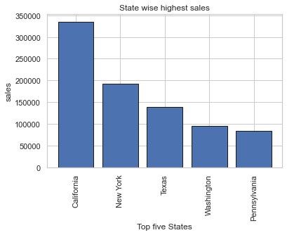

```python
df2 =df2.sort_values("Sales", ascending=False)
Top_5_states=df2.head()
Top_5_states=pd.DataFrame(Top_5_states)
plt.bar(x='State',data=Top_5_states,height='Sales',edgecolor='k')
plt.title('State wise highest sales')
plt.xlabel('Top five States')
plt.ylabel('sales')
plt.xticks(rotation=90)
```

Insights: This graph depicts the 5 highest state wise sales, in which California tops the chart. According to the plot the sales of california is around 330000 - 340000 units which contributes almost around 20 Precent of the total sales.

### 5.Percentage share of profit of every region

```python
df3 =pd.read_excel(r"C:\Users\vishnus4\Documents\AI\Capstone\Capstone7_Time Series\Region_State_Mapping.xlsx")
df3.head()
```

|  | State_Code | Region_ID |
| --- | --- | --- |
| 0 | S01 | R2 |
| 1 | S02 | R4 |
| 2 | S03 | R2 |
| 3 | S04 | R4 |
| 4 | S05 | R4 |

##### State wise profit

```python
state_total = df.groupby(['State_Code']).sum()['Profit']
state_total = pd.DataFrame(state_total)
state_total = state_total.reset_index()
state_total.head()
```

|  | State_Code | Profit |
| --- | --- | --- |
| 0 | S01 | 3908.6469 |
| 1 | S02 | -2844.9334 |
| 2 | S03 | 2847.2149 |
| 3 | S04 | 55101.0159 |
| 4 | S05 | -2896.7289 |

##### Merging state code and region ID

```python
df4 = pd.merge(df3,state_total,how = 'inner')
df4.head(10)
```

|  | State_Code | Region_ID | Profit |
| --- | --- | --- | --- |
| 0 | S01 | R2 | 3908.6469 |
| 1 | S02 | R4 | -2844.9334 |
| 2 | S03 | R2 | 2847.2149 |
| 3 | S04 | R4 | 55101.0159 |
| 4 | S05 | R4 | -2896.7289 |
| 5 | S06 | R3 | 3511.4918 |
| 6 | S07 | R3 | 3754.1431 |
| 7 | S08 | R3 | 1059.5893 |
| 8 | S09 | R2 | -658.8620 |
| 9 | S10 | R2 | 7360.4028 |

##### Region wise profit

```python
region_profit = df4.groupby(['Region_ID']).sum()['Profit']
region_profit = region_profit.reset_index()
region_profit
```

|  | Region_ID | Profit |
| --- | --- | --- |
| 0 | R2 | 37833.6906 |
| 1 | R3 | 47928.6939 |
| 2 | R4 | 72966.1850 |
| 3 | R5 | 19525.7880 |

##### Merging the region wise profit with their respective region names and calculating the percentage share

```python
df5 =pd.read_excel(r"C:\Users\vishnus4\Documents\AI\Capstone\Capstone7_Time Series\Tables\Region_Table.xlsx")
total_profit = df4["Profit"].sum()
total_profit = round(total_profit,2)
df5 = pd.merge(region_profit,df5,how = 'inner')
df5['Percentage'] = df5['Profit']/total_profit*100
df5
```

|  | Region_ID | Profit | Region_Name | Percentage |
| --- | --- | --- | --- | --- |
| 0 | R2 | 37833.6906 | South | 21.224553 |
| 1 | R3 | 47928.6939 | East | 26.887810 |
| 2 | R4 | 72966.1850 | West | 40.933745 |
| 3 | R5 | 19525.7880 | Central | 10.953891 |

##### Graphical representation of percentage share profit of every region

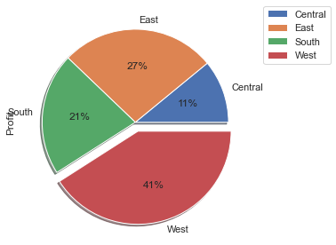

```python
explode = (0, 0, 0, 0.1)
df5.groupby(['Region_Name']).sum().plot(kind='pie', y='Profit',autopct='%1.0f%%',explode=explode,shadow=True)
plt.tight_layout()
plt.legend(bbox_to_anchor=(1.05, 1), loc=2, borderaxespad=0.)
plt.show()
```

Insights: As the pie chart clearly depicts the region wise profit shares, out of the total profit almost 41% of it is contibuted by the western region, the highest and followed by which, is the eastern region almost contributing around 27% of the total profit share.

### 6. Most valuable customer

```python
cust=df.groupby(['Customer_ID','Customer_Name'])['Quantity'].sum()
cust_max = cust.max()
cust = pd.DataFrame(cust)
cust[cust["Quantity"]==cust_max]
```

| Customer_ID | Customer_Name | Quantity |
| --- | --- | --- |
| WB-21850 | William Brown | 141 |

```python
cust = cust.sort_values("Quantity", ascending=False)
Top_10_Cust = cust.head(10)
Top_10_Cust = pd.DataFrame(Top_10_Cust)
Top_10_Cust
```

| Customer_ID | Customer_Name | Quantity |
| --- | --- | --- |
| WB-21850 | William Brown | 141 |
| JL-15835 | John Lee | 140 |
| PP-18955 | Paul Prost | 131 |
| SC-20725 | Steven Cartwright | 129 |
| JD-15895 | Jonathan Doherty | 128 |
| CK-12205 | Chloris Kastensmidt | 122 |
| EP-13915 | Emily Phan | 121 |
| MA-17560 | Matt Abelman | 117 |
| NS-18640 | Noel Staavos | 113 |
| LC-16870 | Lena Cacioppo | 113 |